# Lab #3

Jay Maxwell

#### DS202

#### Fall 2020

```r
##  DATA CLEANING   ##
#  RENAME THE COLUMNS
# change to factors where needed
# get rid of responses we don't need
# drop all the na
`%notin%` = function(x,y) !(x %in% y)


dat <- dat %>%
  rename(party='Political party affiliation',
                      edu = 'Highest year of school completed',
                      married = 'Marital status',
                      age = 'Age of respondent',
                      income = 'Total family income',
                      happy = 'General happiness') %>%
  mutate(party = factor(party),
         edu=factor(edu),
         married=factor(married),
         age=factor(age),
         income=factor(income),
         happy=factor(happy)) %>%
  filter(happy %notin% c("Don't know", "No answer", "Not applicable"),
         married %notin% c('Source','No answer'),
         edu %notin% c("Don't know", 'No answer')) %>%
  drop_na()
```

1. Find the average years of education for the respondents with each political party affiliation. Arrange your output in a meaningful order and print. Describe any patterns you find.

```r
dat1 <- dat %>%
  group_by(party) %>%
  #mutate(edu_avg = mean(as.numeric(edu))) %>%
  summarize(edu_avg=mean(as.numeric(edu))) %>%
  select(party,edu_avg) %>%
  #distinct(party, .keep_all = TRUE ) %>%
  arrange(desc(edu_avg))
dat1
```

```
## # A tibble: 10 x 2
##    party              edu_avg
##    <fct>                <dbl>
##  1 Don't know            9.09
##  2 Strong democrat       8.86
##  3 Other party           8.43
##  4 No answer             8.26
##  5 Not str democrat      8.22
##  6 Strong republican     8.20
##  7 Independent           8.04
##  8 Not str republican    7.94
##  9 Ind,near dem          7.94
## 10 Ind,near rep          7.80
```

```r
########################################################
# Jaeyeon's Review and Revision
# You can also try this Jay!
# dat$edu = as.factor(dat$edu)
# dat$party = as.factor(dat$party)
#
# `%notin%` <- Negate(`%in%`)
#
# jaeyeonDat <- dat %>%
#   group_by(party) %>%
#   filter(edu %notin% c("No answer", "Don't know")) %>%
#   summarise(mean_edu = mean(as.numeric(edu))) %>%
#   arrange(desc(mean_edu))
#
# jaeyeonDat
#############################################################
```

The folks who don’t know what party they belong to have the highest mean years of education.

2. Create a single data frame containing records for the better educated respondents in each political party affiliation. A “better educated” respondent is someone who has strictly more years of education than the median in the same party affiliation. Print the structure of the data frame.

```r
dat2 <- dat %>%
  group_by(party) %>%
  mutate(edu_med = median(as.numeric(edu))) %>%
  ungroup() %>%
  filter(as.numeric(edu) > edu_med)

str(dat2)
```

```
## tibble [25,996 x 7] (S3: tbl_df/tbl/data.frame)
##  $ married: Factor w/ 7 levels "Divorced","Married",..: 3 2 3 2 2 1 2 2 2 2 ...
##  $ age    : Factor w/ 75 levels "18","19","20",..: 6 10 10 39 37 32 24 45 29 54 ...
##  $ edu    : Factor w/ 23 levels "0","1","10","11",..: 9 10 9 18 21 20 21 20 10 9 ...
##  $ income : Factor w/ 16 levels "$1000 to 2999",..: 15 15 15 15 15 15 15 15 15 15 ...
##  $ party  : Factor w/ 10 levels "Don't know","Ind,near dem",..: 2 6 2 7 9 6 9 3 2 10 ...
##  $ happy  : Factor w/ 6 levels "Don't know","No answer",..: 4 4 4 5 5 4 6 6 6 5 ...
##  $ edu_med: num [1:25996] 7 6 7 7 7 6 7 7 7 7 ...
```

3. How is the happiness of a respondent related to his/her marriage status? Define that a person is happy if the response to question is “Very happy” or “Pretty happy”.

```r
dat3 <- dat %>% select(happy,married,party)

dat3 <- dat3 %>% group_by(happy,married) %>% summarize(n=n())
```

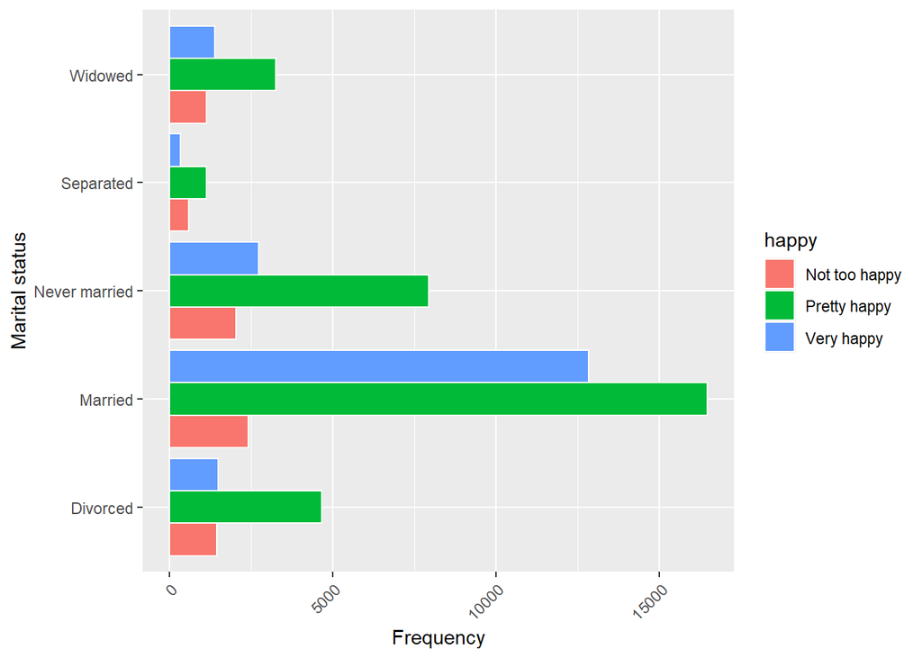

```r
q3plot <- ggplot(dat3, aes(x=married, y=n)) + geom_bar(aes(fill=happy),
                                               stat="identity",
                                               color="white",
                                               position = position_dodge(.9)) +
  theme(axis.text.x = element_text(angle = 45, hjust = 1, vjust = 1)) +
  xlab("Marital status") + ylab('Frequency')

q3plot + coord_flip()
```

Married people had the largest number of happy responses. The largest number of not too happy responses was also in the married category. But so many people are in the married category, it might not be surprising that the number is high too.

4. Does party affiliation affect the relationship you found in the last question?

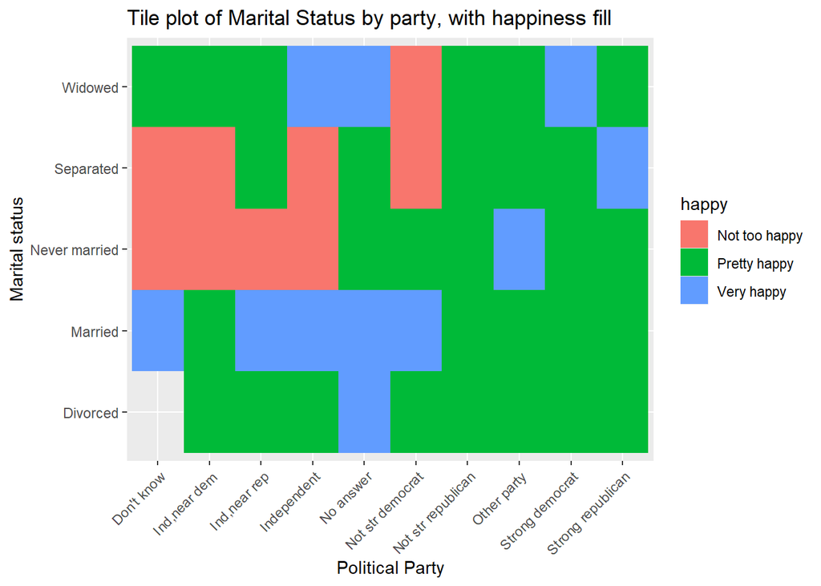

```r
# dat3 <- dat %>%
#   select(happy,married,party) %>%
#   group_by(happy,married) %>%
#   summarize(n=n()) %>%
#   ungroup()
#
# q3plot <- ggplot(dat3, aes(x=married, y=n)) +
#   geom_bar(aes(fill=happy),
#            stat="identity",
#            color="white",
#            position = position_dodge(.9)) +
#   theme(axis.text.x = element_text(angle = 45, hjust = 1, vjust = 1)) +
#   xlab("Marital status") + ylab('Frequency')

#q3plot   + facet_grid(~party)


#ggplot(dat3, aes(x = happy, y=married, fill=party)) +   geom_tile()

ggplot(dat, aes(x = party, y=married, fill=happy)) +   geom_tile() +
  ggtitle("Tile plot of Marital Status by party, with happiness fill") +
  xlab("Political Party") + ylab("Marital status") +
  theme(axis.text.x = element_text(angle = 45, hjust = 1, vjust = 1))
```

A tile plot clearly shows the relations between marital status and political party affiliation.

5. How is marrital status related to the education of a respondent? What are possible reasons accounting for the patterns you see?

```r
dat5 <- dat %>%
  group_by(married) %>%
  select(married,edu) %>%
  summarize(avg_edu=mean(as.numeric(edu), n=n())) %>%
  arrange(avg_edu)
```

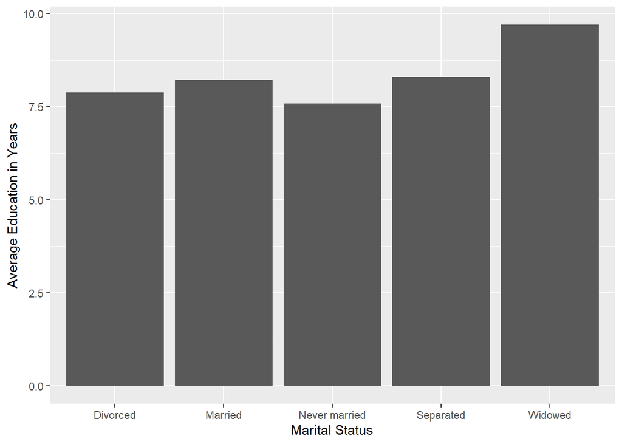

```r
dat5 %>% ggplot(aes(x =married, weight = avg_edu)) + geom_bar() + ylab("Average Education in Years") +xlab("Marital Status")
```

6.2

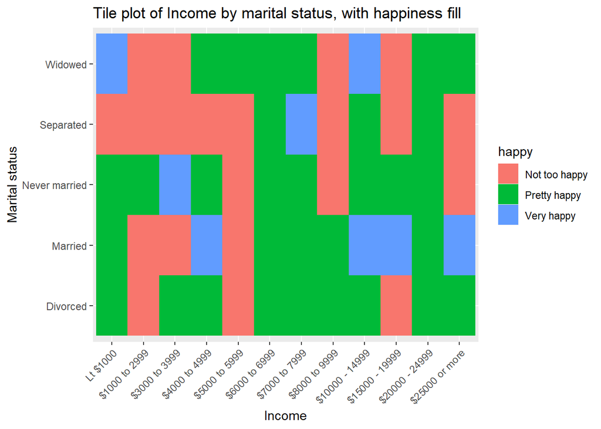

```r
dat$income = factor(dat$income, levels = c("Lt $1000",
                                                        "$1000 to 2999",
                                                        "$3000 to 3999",
                                                        "$4000 to 4999",
                                                        "$5000 to 5999",
                                                        "$6000 to 6999",
                                                        "$7000 to 7999",
                                                        "$8000 to 9999",
                                                        "$10000 - 14999",
                                                        "$15000 - 19999",
                                                        "$20000 - 24999",
                                                        "$25000 or more",
                                                        "Don't know",
                                                        "No answer",
                                                        "Not applicable",
                                                        "Refused"))
dat6 <- dat %>%
filter(income %notin% c("Don't know", "No answer", "Not applicable", "Refused")) %>%
  ggplot(aes(x = income, y=married, fill=happy)) +   geom_tile() +
  ggtitle("Tile plot of Income by marital status, with happiness fill") +
  xlab("Income") + ylab("Marital status") +
  theme(axis.text.x = element_text(angle = 45, hjust = 1, vjust = 1))

dat6
```